# Stat 202: Lecture 2 (covers pp. 22-33)

Nathan VanHoudnos  
9/26/2014

### Agenda

1. Homework #1 comments
2. Checkpoint #1 results
3. Lecture 2 (covers pp. 22-33)

### Homework #1 comments

- Having laptop problems? Go to Laptop ER:
  - 1:00 - 4:00 p.m. **today**
  - at Norris University Center, across from the University bookstore
  - first-come-first serve
  - info: http://www.it.northwestern.edu/laptoper/
- NU IT is installing R & RStudio in the library
  - This will **not** be ready until after HW 1 is due.
  - If you can't get them installed on your machine, then **borrow** a friend's machine for this assignment. (**Do your own assignment!**)

### Homework #1 comments

- If the *.Rmd file does not open when you double-click on it, then **open** it directly in RStudio. (Demo)
- Follow the directions on the homework.
  - Steps 1-4: Make sure that RStudio is working
  - Step 7: Saves you time:

> Step 7: After every question, click the **Knit HTML** button to make sure that the output is as expected.

### Homework #1 comments

- Asking me questions is encouraged. I will respond!
- However, **it is disrespectful to waste my time.**
  - Do not ask me questions that you can answer yourself with a little bit of effort.
  - *“Thanks, I already figured it out.”* implies that you did not need to ask the question!

### Agenda

1. Homework #1 comments
2. Checkpoint #1 results
3. Lecture 2 (covers pp. 22-33)

### Checkpoint #1 results

**Academic integrity**

- The checkpoints are **quizzes**, they are to be your work **alone**.
- I will update the syllabus to clarify

**Notes**

- 68 of 75 students have signed up on OLI
- 64 of 68 took the Checkpoint
  - 1 student took Checkpoint #2 instead
- Average percent correct: **90%**
- If you have questions, see me or Aaron

### Agenda

1. Homework #1 comments
2. Checkpoint #1 results
3. Lecture 2 (covers pp. 22-33)

### Motivation for today:

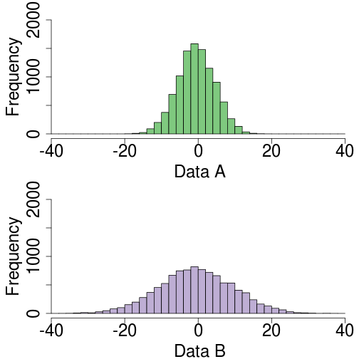

These two distributions have …

- the same shape
- the same center
- **different spreads**
  - Range
  - Inter-quartile range (IQR)
  - Standard deviation

### Measures of spread

**Age at Oscar**

```
  2 | 1
  2 | 56669
  3 | 013333444
  3 | 555789
  4 | 11123
  4 | 599
  5 |
  5 |
  6 | 1
  6 |
  7 | 4
  7 |
  8 | 0
```

- **Range:**
  - Max - Min
  - 80 - 21 = 59
  - *All* data in range
- **Inter-Quartile Range**
  - 50% of data \( \le \) **median**
  - 25% of data \( \le \) **Q1**
  - 75% of data \( \le \) **Q3**
  - **IQR** = Q3 - Q1
  - *50%* of data in IQR

### IQR by hand example

**Lowest**

```
  2 | 1
  2 | 56669
  3 | 013333444
  3 | 5
```

**Highest**

```
  3 | 55789
  4 | 11123599
  5 |
  6 | 1
  7 | 4
  8 | 0
```

- Q1 \( \approx \) median of lowest half
  - 32
- Q3 \( \approx \) median of highest half
  - 41.5
- IQR \( \approx \) 41.5 - 32
  - 9.5 years

### IQR by R example

```r
head(oscars.df, n=3) ## First three records
```

```
  year age
1 1970  34
2 1971  34
3 1972  26
```

```r
summary(oscars.df$age)
```

```
   Min. 1st Qu.  Median    Mean 3rd Qu.    Max.
   21.0    32.5    35.0    38.5    41.2    80.0
```

**However**: 41.2 - 32.5 = 8.7 \( \ne \) 9.5

### R and "by hand" disagree!

This is **earth-shattering**.

> Is R wrong? **or** Am I teaching you lies?

Answer: **Neither.**

- R implements **nine** methods (including “by hand”) to calculate quartiles
- Some methods are better **estimators** than others
- The default of `summary()` is among the best
- The “by hand” method is among the worst

### Q1, Q3, and IQR are a little tricky

OLI textbook, p. 24, emphasis mine:

> Note that Q1 and Q3 as reported by the various software packages differ from each other and are also slightly different from the ones we found [by hand]. **This should not worry you.**

**It should pique your intellectual curiosity.**

For this course, I will ask you to use

- the “by hand” method for tests & quizzes, and
- the R `summary` method for homeworks.

### Using IQR: Outliers

Outliers are suspected if an observation is

- below \( \left( \text{Q1} - 1.5 \times \text{IQR}\right) \) or
- above \( \left( \text{Q3} + 1.5 \times \text{IQR}\right) \)

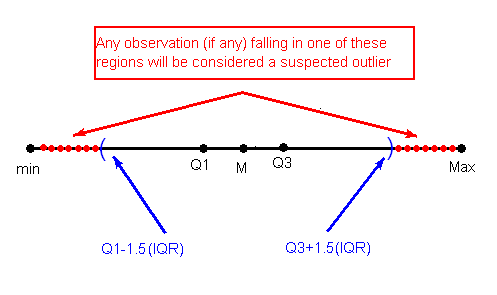

### Example: 1.5 IQR rule

**Age at Oscar**

```
  2 | 1
  2 | 56669
  3 | 013333444
  3 | 555789
  4 | 11123
  4 | 599
  5 |
  5 |
  6 | 1
  6 |
  7 | 4
  7 |
  8 | 0
```

Recall

- Q1 = 32 and Q3 = 41.5

Which data points, if any, are suspected outliers?

- IQR = 41.5 - 32 = 9.5
- 1.5 IQR = 14.25
- Q1 - 1.5 IQR = 17.75
- Q3 + 1.5 IQR = 55.75
- suspect 61, 74, and 80

### Handling outliers: It depends

Roughly three types of outliers:

1. Same data-generating process
2. Different data-generating process
3. Mistakes

### Outlier from same process

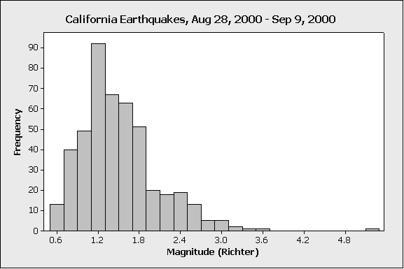

**Earthquakes**

- the largest quakes can be the most important!
- removing such a data point might be a terrible idea

### Outlier from different process

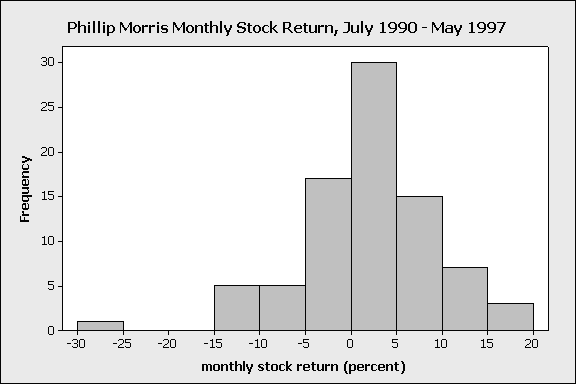

**Stock Prices**

- Highly-publicized anti-smoking congressional hearings
- Large negative pressure for stock price
- Can remove outlier **if** interested in typical returns

### Outlier from mistake

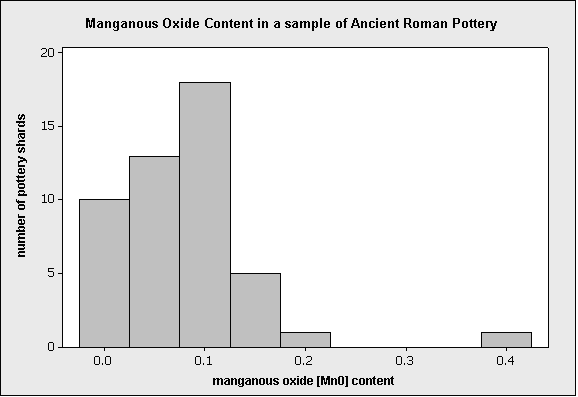

**Archaeology**

- Likely that '.394' was really '.094'
- Often **useful** to remove outlier

### Outlier from mistake

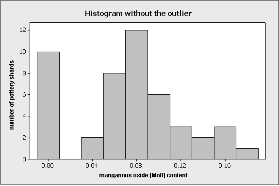

**Archaeology**

- Likely that '.394' was really '.094'
- Often **useful** to remove outlier

### Boxplots: 5 number summary

**Age at Oscar**

```
  2 | 1
  2 | 56669
  3 | 013333444
  3 | 555789
  4 | 11123
  4 | 599
  5 |
  5 |
  6 | 1
  6 |
  7 | 4
  7 |
  8 | 0
```

**5 number summary**

```
Min. Q1  Median Q3   Max.
21   32  35     41.5 80
```

**Boxplot**

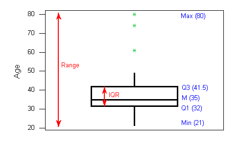

### Boxplots in R

```r
summary(oscars.df$age)
```

```
   Min. 1st Qu.  Median    Mean 3rd Qu.    Max.
   21.0    32.5    35.0    38.5    41.2    80.0
```

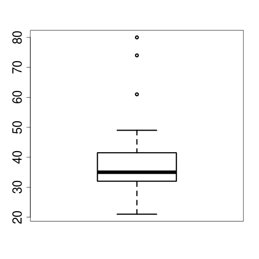

```r
boxplot(oscars.df$age)
```

### BRFSS Boxplots

**Height in inches**

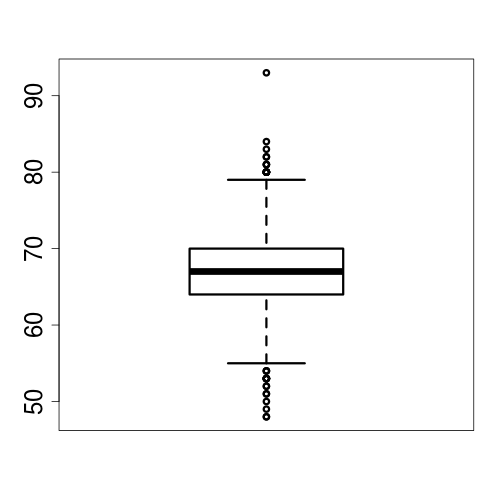

What is the height of

- the tallest person?
  - 93 in. (7' 9")
- the shortest person?
  - 48 in. (4')

I am taller than ¾ of people. How tall am I?

- Q3 = 70 in. (5' 10")

### BRFSS Boxplots

**Age**

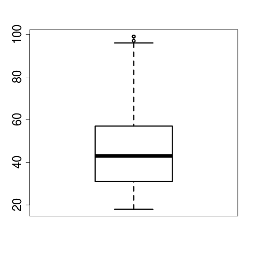

Is this distribution symmetric, right-skewed, or left-skewed?

- **right-skewed**

Approximately what percentage of people are under 60?

- **A little over 75%**

### Side-by-side Boxplots

**Age**

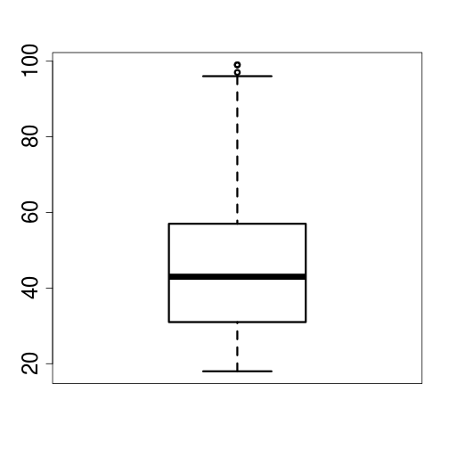

**Age by General Health**

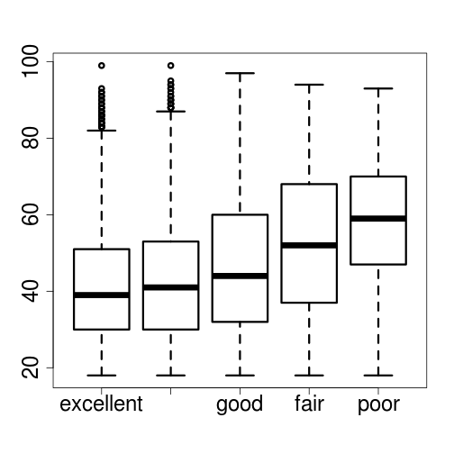

### Side-by-side Boxplots

**Age by General Health**

Compare and contrast

- **Shape**
  - Excellent: right-skewed
  - Poor: symmetric
- **Center**
  - Excellent: typically 40 years
  - Poor: typically 60 years

### Side-by-side Boxplots

**Age by General Health**

Compare and contrast

- **Spread**
  - Both groups have similar IQR
  - Nearly 75% of people in excellent health are younger than than the youngest 25% of people in poor health.

### Side-by-side Boxplots

**Age by General Health**

Compare and contrast

- **Deviations from pattern**
  - The oldest people rate themselves in excellent health.
  - These outliers are **likely** to occur again and should be kept.

### Tell me a story...

**Weight by gender**

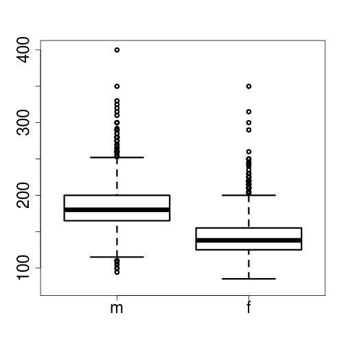

**Desired Weight**

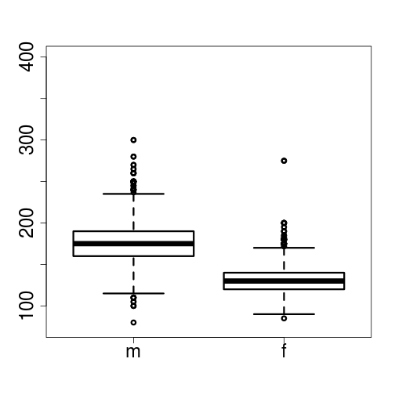

### Motivation for today:

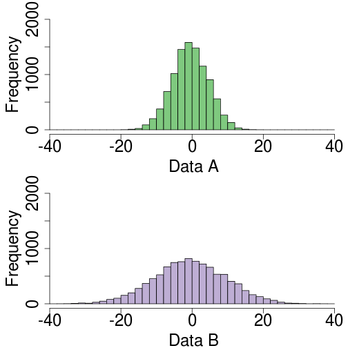

These two distributions have …

- the same shape
- the same center
- different spreads
  - Range
  - Inter-quartile range (IQR)
  - **Standard deviation**

### Standard deviation: Calculation

| Data_D | 7 | 9 | 5 | 13 | 3 | 11 | 15 | 9 |
| --- | --- | --- | --- | --- | --- | --- | --- | --- |

Step 1. Find the mean (\( \bar{x} = 9 \)).

Step 2. Find the deviations from the mean:

| Deviations | -2 | 0 | -4 | 4 | -6 | 2 | 6 | 0 |
| --- | --- | --- | --- | --- | --- | --- | --- | --- |

Step 3. Square the deviations:

| Squared Deviations | 4 | 0 | 16 | 16 | 36 | 4 | 36 | 0 |
| --- | --- | --- | --- | --- | --- | --- | --- | --- |

### Standard deviation: Calculation

| Data_D | 7 | 9 | 5 | 13 | 3 | 11 | 15 | 9 |
| --- | --- | --- | --- | --- | --- | --- | --- | --- |
| Deviations | -2 | 0 | -4 | 4 | -6 | 2 | 6 | 0 |
| Squared Deviations | 4 | 0 | 16 | 16 | 36 | 4 | 36 | 0 |

Step 4: Sum the squared deviations (\( 112 \)).

Step 5: Divide the sum by \( n-1 \), i.e. one less than the sample size \[ \frac{112}{8 -1 } = 16 \]

- This quantity is the **variance**.

Step 6: **Standard deviation** square root of variance ( sd = 4 )

### Standard deviation: Comments

- R will do a standard deviation calculation for you:

```r
sd(Data_D)
```

```
[1] 4
```

- It is more important that you **understand the properties** of the standard deviation than that you can calculate it.
- The standard deviation has useful properties for a **special** distribution: the **normal** distribution

### Normal distributions

**A normal distribution**

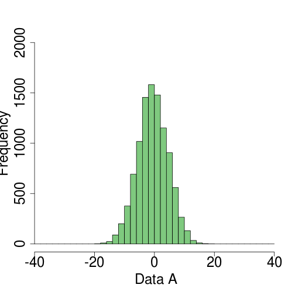

Three characteristics of normal distributions:

- unimodal,
- symmetric, and
- has no outliers.

Normal distributions are **surprisingly** common.

### SD Rule for Normal Distributions

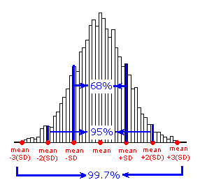

Approximately

- 68% within 1 sd of the mean.
- 95% within 2 sd of the mean.
- 99.7% (or virtually all) within 3 sd of the mean.

### 68/95/99.7 rule example:

The body temperatures of dogs are normally distributed with a mean of 101.3 F and a standard deviation of 0.6 F.

### Comparing measures

The **IQR** is to the **median** as the **standard deviation** is to the **mean**.

- Use the mean and standard deviation if a distribution is:
  - unimodal
  - symmetric, and
  - has no outliers.
- Otherwise use the median and IQR.
- **SD Rule only if a distribution is normal.**

### Quick check:

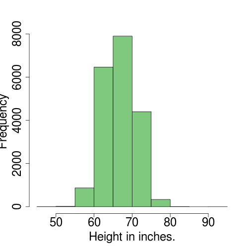

Mean and SD or Median and IQR?

- Mean and SD

Can we use the SD rule?

- No. We were not told this is a normal distribution.

### Quick check:

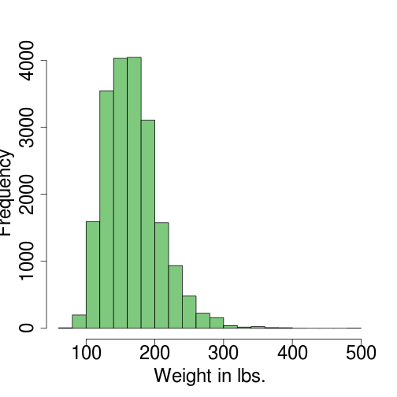

Mean and SD or Median and IQR?

- Median and IQR

Can we use the SD rule?

- No. The distribution is skewed, therefore it is not normal.